# Team project: Final Submission

MoneyBall strategy in the English Premier League

Juan Pablo Jaramillo & Varun Vijayakumar - TEAM 2

ATTENTION!! PLEASE RUN ALL THE CODE ON THE NOTEBOOK: “TEAM 2 - CODE”. THIS IS TO ENSURE TO ENSURE ALL THE VARIABLES USED IN THIS MODEL ARE IN THE GLOBAL ENVIRONMENT BEFORE LOOKING THROUGH THE FINAL PROJECT SUBMISSION BELOW.

SHORTCUT TO RUN ALL THE CODE IN A NOTEBOOK: COMMAND + OPTION + R

# Set-up

```r
library(tidyverse)
library(broom)
# load other packages AS NEEDED and ONLY IF YOU *REALLY* NEED THEM
# If you load other packages, **explain why you need them**. If you cannot explain why, not good!
```

# 1 Introduction

In the English Premier League (EPL), it’s pretty much said that the traditional big teams win year on year, mainly because of their economical power and access to funding. After having read the book ‘Money Ball’, we believed there could be a way to replicate this strategy within the EPL in order to allow smaller teams with far less access to funding to be able to compete with the traditionally bigger teams such as; Chelsea, Manchester City etc. In 2016, Leicester City took everyone by surprise and won the EPL title however people all over the world saw this as a lucky win. We aim to help Leicester City, with the help of statistics rather than intuition, get back on the road to victory in the 2020 football season.

In order to put it in perspective, in the 2020 season, Leicester City have 30million allocated to buy players, whereas a team such as Chelsea have 120million. Normally in a situation like this, Leicester would have no chance in being able to buy players to the extent Chelsea do. Over the last 20 years, the following teams have won the EPL: Manchester United (7), Liverpool (1), Manchester City (4), Chelsea (5), Leicester (1), Arsenal (2). Because of this, it is almost certain that football supporters that do not live in England will support one of the traditionally big teams (Manchester United, Chelsea, Manchester City, Arsenal etc.) as they are the ones heavily advertised worldwide. The result of this is these teams get bigger and bigger from a financial standpoint, whereas a team like Leicester is far from growing at the same rate.

## 1.1 Objective

**Goal**: Using a predictive model, this analysis aims to build a championship winning team for Leicester city given their limited budget.

The strategy we propose aims to find undervalued players that possess the specific skill set to play in each of their positions, as done by Billy Beane within Baseball. We hope once this strategy is implemented, it gives Leicester City a better fighting chance to win the league as oppose to being happy if they finish in the Top 10 at the end of the season as per the norm. The focus was on building a model for Leicester that enables them to identify talent that was not picked up by bigger clubs. These players may not have been considered due to inconsequential reasons that do not hinder performance.

Five main playing positions have been identified and we will be looking to pick players that have the specific skill set for their respective positions and disregard everything else.

As a result, the model gives us the lowest priced top players for each position whom have two to three of the main skills for that position. Adding on to that, using linear models we were able to build a predictive pricing model for each position which enabled us to evaluate whether a particular player was undervalued/overvalues. These results can now be analyzed by the manager at Leciester, Brendan Rodgers, which will allow him to make the most effective purchases in this year’s transfer window.

# 2 Data

Dataset used: FIFA 19 complete player database Date: December 21, 2018

[Link to data](https://www.kaggle.com/karangadiya/fifa19)

## 2.1 Reliability of Information

The data we have used in order to build our model is from the FIFA 19 game. Electronic Arts (EA) sports spends a lot of time and money to make sure player statistics and information are as up-to-date as can be. They “employ a team of 25 EA Producers and 400 outside data contributors, who are led by Head of Data Collection & Licensing, Michael Mueller-Moehring. This team is responsible for ensuring all player data is up to date, whilst a community of over 6,000 FIFA Data Reviewers and Talent Scouts from all over the world are constantly providing suggestions and alterations to the database.”

See more

## 2.2 Load Database

```r
fifa_data  <- read.csv('data/fifa.raw.data.csv') #Import function used
```

# 3 Analysis

## 3.1 Exploratory Analysis

To kick things off and get a feel for the variables and distributions present in the dataset, we did some exploratory analysis. The results are as follows:

### 3.1.1 Figure 1: Histogram of Overall Scores of players.

**Comment**: As shown below, the distribution of Overall player scores are normally distributed. This is a positive sign as this data can be used in further analysis without transformation.

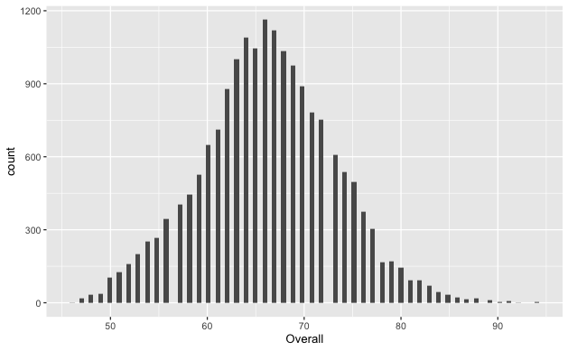

```r
fifa_data %>%
  ggplot(aes(x = Overall))+
  geom_histogram(bins = 100)
```

### 3.1.2 Figure 2: Scatter plot between Price and Overall score

**Comment:** The below scatter plot shows a non-linear relationship between Price and Overall score. Price, being the dependent variable on the Y-axis, needs to be transformed.

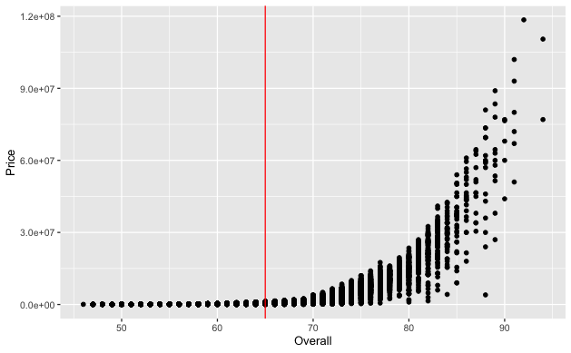

```r
fifa_data %>%
  filter(Price > 0) %>%
  ggplot(data = .,aes(x = Overall, y= Price))+
  geom_point()+
  geom_vline(xintercept = 65, color = "Red")
```

### 3.1.3 Figure 2.1: Effect of Log transformation on Price

**Comment:** The best method of transformation when the variable has very low values as well as extremely high ones is the Log transformation. Below we observe that once “Price” has been transformed to “log_price”, the relationship with Overall score is one that is linear. It is important to note that we have performed the transformation primarily, in this case, to move forward with a linear regression between these two variables.

```r
#TRANSFORMATION OF PRICE
fifa_data <- fifa_data %>%
  mutate(log_price = log(Price))
```

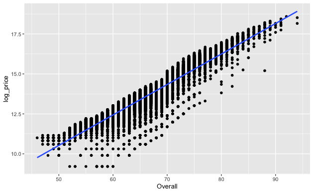

```r
#Scatter plot after transformation
fifa_data %>%
  filter(Price > 0) %>%
  ggplot(data = .,aes(x = Overall, y= log_price))+
  geom_point()+
  geom_smooth(method = "lm")
```

### 3.1.4 Figure 3: Linear Regression Summary

**Comment:**The R-squared of this model is 88.06% which means that 88% of the variation in “log_price” can be explained by the players “Overall” score. Price = 0 excluded because log(0) = -infinity which would distort the results. It can also be observed that there is a positive relationship between the two variables being analysed.

```r
fifa_data %>%
  filter(Price > 0) %>%
  lm(formula = log_price ~ Overall, data = .) %>%
  summary()
```

```
Call:
lm(formula = log_price ~ Overall, data = .)

Residuals:
    Min      1Q  Median      3Q     Max
-3.2226 -0.2069  0.0638  0.3184  1.2384

Coefficients:
             Estimate Std. Error t value Pr(>|t|)
(Intercept) 0.9933480  0.0348885   28.47   <2e-16 ***
Overall     0.1906596  0.0005239  363.90   <2e-16 ***
---
Signif. codes:  0 ‘***’ 0.001 ‘**’ 0.01 ‘*’ 0.05 ‘.’ 0.1 ‘ ’ 1

Residual standard error: 0.4859 on 17953 degrees of freedom
Multiple R-squared:  0.8806,    Adjusted R-squared:  0.8806
F-statistic: 1.324e+05 on 1 and 17953 DF,  p-value: < 2.2e-16
```

### 3.1.5 Figure 4: Analysis of relationship between salary and price of players

**Comment:** Moving on we thought it would be a good idea to analyze the “Price” of football players vs their weekly “Salaries”. Salary and Price and positively correlated however it can be seen that when price exceeds £30million the dispersion between price and salary start to increase significantly.

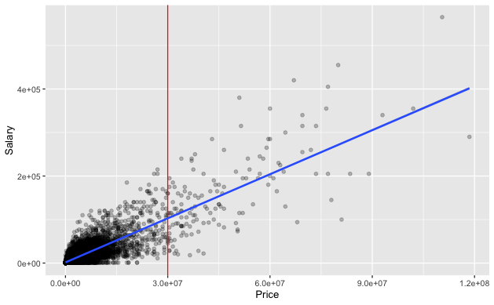

```r
fifa_data %>%
  ggplot(data = ., aes(x = Price, y = Salary))+
  geom_point(alpha = 0.25)+
  geom_vline(xintercept = 30000000, color = "red")+
  geom_smooth(method = "lm")
```

## 3.2 In depth Analysis

Having a basic idea of the price of players and their salaries, in relation to their overall scores, we wanted to proceed building our model in the following steps: - Player grouping - Price analysis - Linear Models (Identification of significant skills per position) -> Setting benchmarks -> Predicting Player Prices with Linear regression formula - Player Identification process

### 3.2.1 Player Grouping

```r
fifa_data <- fifa_data %>%
  mutate(Grouped_Position = ifelse(fifa_data$Position == 'RF', 'STRIKER',
                        ifelse(fifa_data$Position == 'CAM', 'MIDFIELD',
                        ifelse(fifa_data$Position == 'CB', 'DEFENCE',
                        ifelse(fifa_data$Position == 'CDM', 'MIDFIELD',
                        ifelse(fifa_data$Position == 'CF', 'STRIKER',
                        ifelse(fifa_data$Position == 'CM', 'MIDFIELD',
                        ifelse(fifa_data$Position == 'GK', 'GOAL-KEEPER',
                        ifelse(fifa_data$Position == 'LAM', 'MIDFIELD',
                        ifelse(fifa_data$Position == 'LB', 'DEFENCE',
                        ifelse(fifa_data$Position == 'LCB', 'DEFENCE',
                        ifelse(fifa_data$Position == 'LDM', 'MIDFIELD',
                        ifelse(fifa_data$Position == 'LCM', 'MIDFIELD',
                        ifelse(fifa_data$Position == 'LF', 'WING',
                        ifelse(fifa_data$Position == 'LM', 'MIDFIELD',
                        ifelse(fifa_data$Position == 'LW', 'WING',
                        ifelse(fifa_data$Position == 'LWB', 'DEFENCE',
                        ifelse(fifa_data$Position == 'RAM', 'MIDFIELD',
                        ifelse(fifa_data$Position == 'RB', 'DEFENCE',
                        ifelse(fifa_data$Position == 'RCB', 'DEFENCE',
                        ifelse(fifa_data$Position == 'RCM', 'MIDFIELD',
                        ifelse(fifa_data$Position == 'RDM', 'MIDFIELD',
                        ifelse(fifa_data$Position == 'RF', 'STRIKER',
                        ifelse(fifa_data$Position == 'RM', 'MIDFIELD',
                        ifelse(fifa_data$Position == 'RS', 'STRIKER',
                        ifelse(fifa_data$Position == 'RW', 'WING',
                        ifelse(fifa_data$Position == 'RWB', 'DEFENCE',
                        ifelse(fifa_data$Position == 'ST', 'STRIKER',
                        ifelse(fifa_data$Position == 'LS', 'STRIKER',
                        'other')))))))))))))))))))))))))))))
```

**Comment:** The ‘other’ category is defined by players that have not been assigned a playing position.

### 3.2.2 Price analysis

```r
quantile(fifa_data$Price)
```

```
       0%       25%       50%       75%      100%
        0    300000    675000   2000000 118500000
```

From there, Q75 was created in order to plot the quartiles again and see how the upper 25% of the data is distributed. This yeilded a result showing a revised Q3 value of USD 9,000,000.

```r
# Selecting the Q75 = 2000000
Q75 <- fifa_data %>%
  filter(.data = ., Price !=0 & Price > 2000000)
```

```r
# Understanding the distribution of the upper 25% or Q75
quantile(Q75$Price)
```

```
       0%       25%       50%       75%      100%
  2100000   3200000   5000000   9000000 118500000
```

**Assumptions**

1. Using a hypothesized value of 25%, we made the assumption that players priced, in revised dataset, more than $9,000,000 were considered “Super Stars”. In other words, player’s with prices above USD 9,000,000 are the top 25% of the revised data.
2. It was also assumed that players with an “International Reputation” of greater than 4 (on a scale of 1:5) were “Super Stars”

To begin our analysis, we created two data sets. The first one, named fifa_data_avg_player (Players valued < USD9.000.000 & International reputation < 4) and the second fifa_superstars (Players valued > USD9.000.000).

```r
fifa_data_avg_player <- fifa_data %>%
  filter(.data = ., Price < 9000000 & International.Reputation < 4) #Data frame to work with

fifa_superstars <- fifa_data %>%
  filter(., Price > 9000000)  #number of superstar that are valued over $9,000,000
```